# STAT 385 Statistics Programming Methods - Fall 2020

### Adding axes, labels, and legends to plots

Suppose now we have a bar plot.

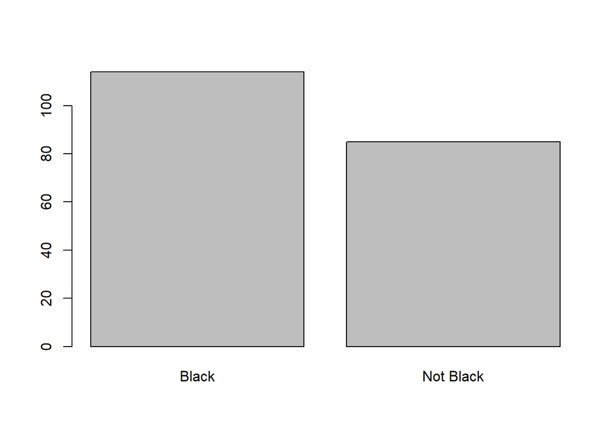

```r
# a bar plot
jail$race2 <- ifelse(jail$race=="Black","Black","Not Black")
plot(factor(jail$race2))
```

Adding a **title** and **subtitle** with `title()` function

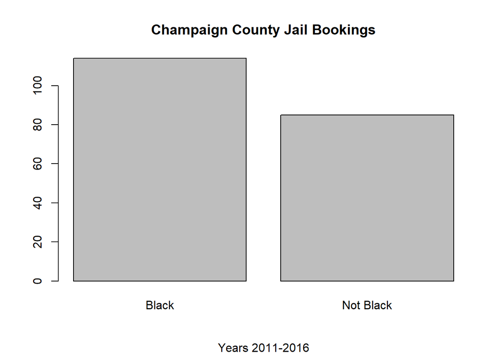

```r
plot(factor(jail$race2), )
title("Champaign County Jail Bookings", "Years 2011-2016") #second argument is a subtitle
```

Adding a custom legend with the `legend()` function.

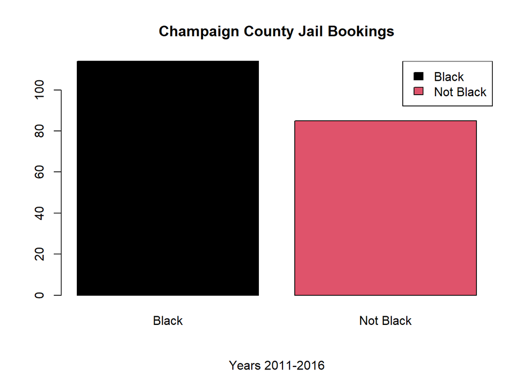

```r
levs <- levels(factor(jail$race2))
plot(factor(jail$race2), col=1:length(levs))
title("Champaign County Jail Bookings", "Years 2011-2016") #second argument is a subtitle
legend("topright", legend=levs, fill=1:length(levs))
```

Suppressing the axis in order to add a custom axis with the `axis` function. We may need multiple axis functions for labeling each particular axis

```r
pl <- plot(factor(jail$race2), axes=FALSE)
pl
```

```
##      [,1]
## [1,]  0.7
## [2,]  1.9
```

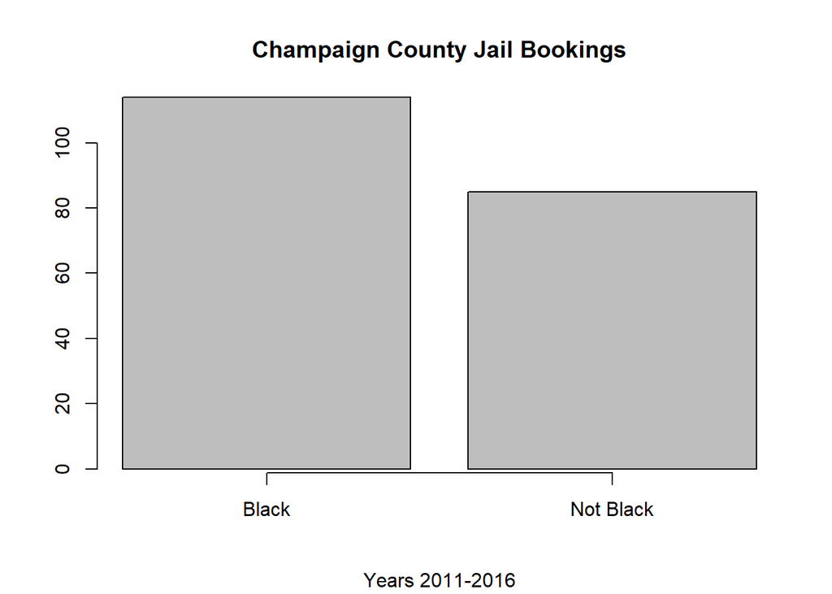

```r
title("Champaign County Jail Bookings", "Years 2011-2016") #second argument is a subtitle
axis(side=1, at=pl, labels=c("Black", "Not Black"))
axis(side=2, xpd=TRUE)
```

### Adding transparency to points

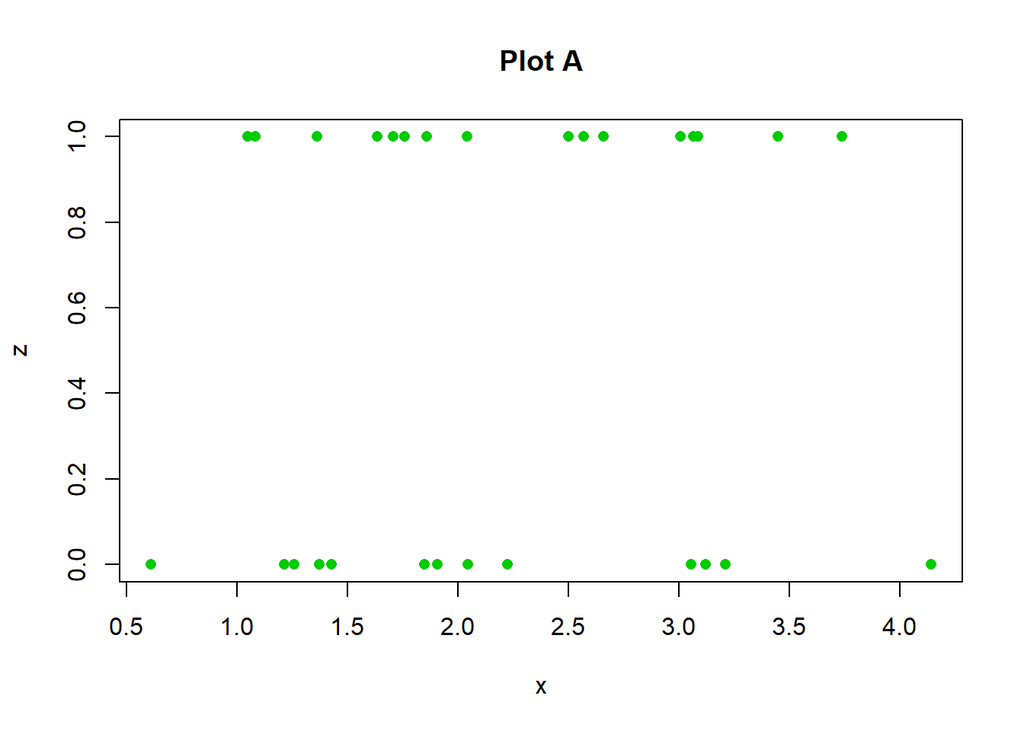

```r
x <- sort(rnorm(30)+2)
y <- sort(rnorm(30))
z <- round(runif(30,0,1))
plot(x,z, col=rgb(0,204/255,0,alpha=1), pch=16, main="Plot A")
```

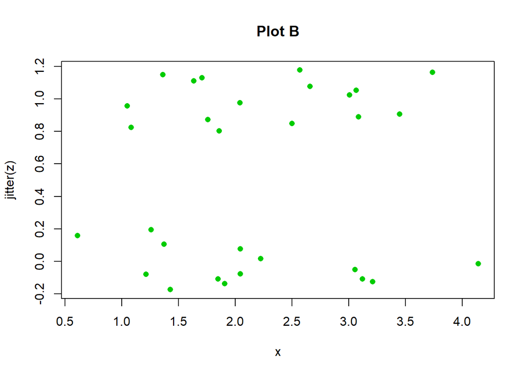

```r
plot(x,jitter(z), col=rgb(0,204/255,0,alpha=1), pch=16, main="Plot B")
```

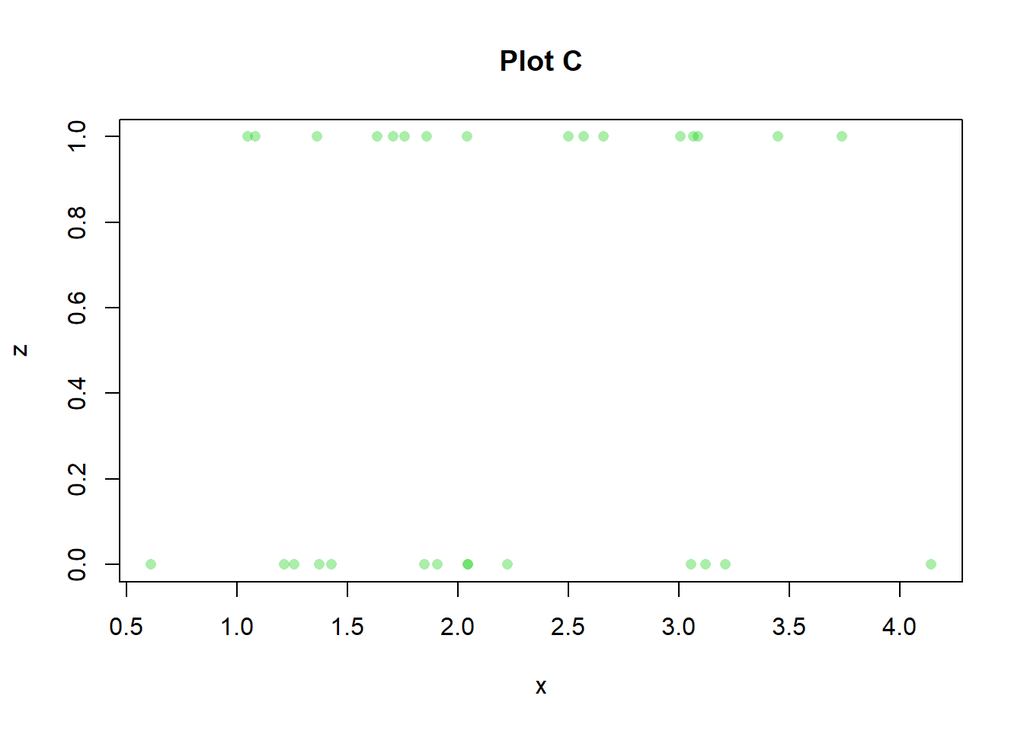

```r
plot(x,z, col=rgb(0,204/255,0,alpha=0.333), pch=16, main="Plot C")
```

### Showing multiple plots in a single graphics device

The par function gives us control over graphical parameters in R. Often we may use it to show multiple plots in a single graphics device by adjusting the matrix for that graphics device. Graphics devices are defaulted to be a 1 by 1 matrix.

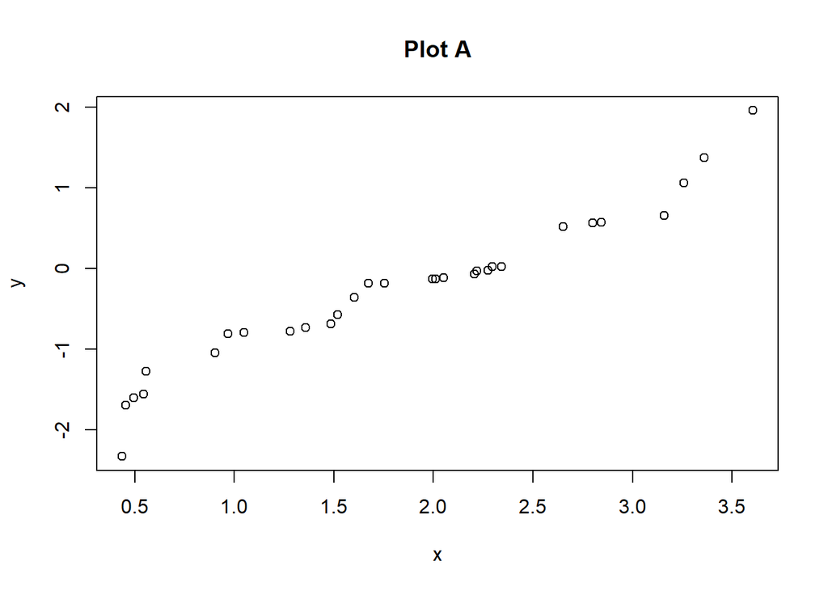

```r
x <- sort(rnorm(30)+2)
y <- sort(rnorm(30))
plot(x,y, main="Plot A")
```

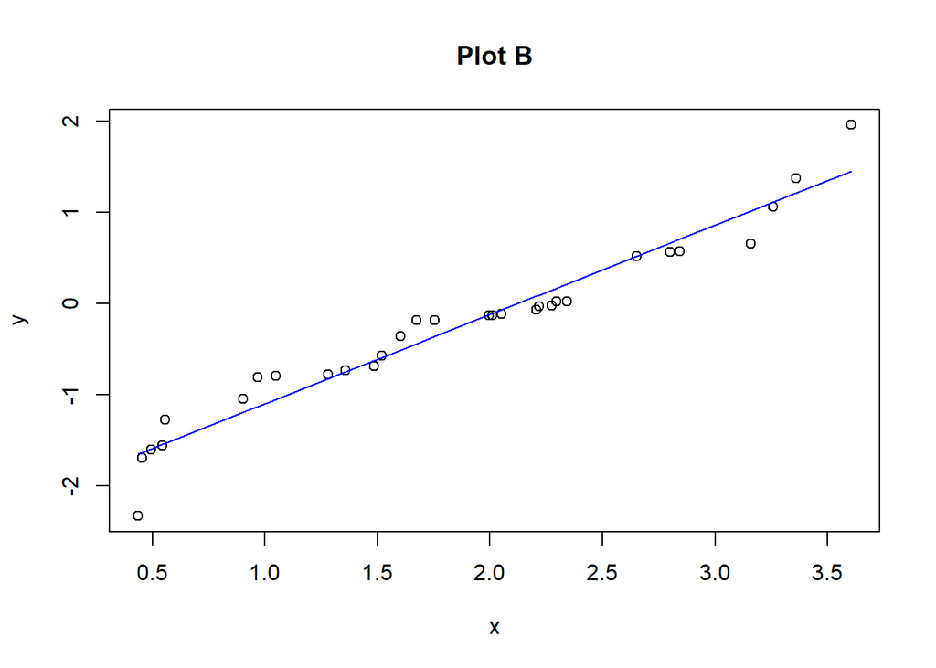

```r
plot(x,y, main="Plot B")
lines(x,lm(y~x)$fit, col="blue")
```

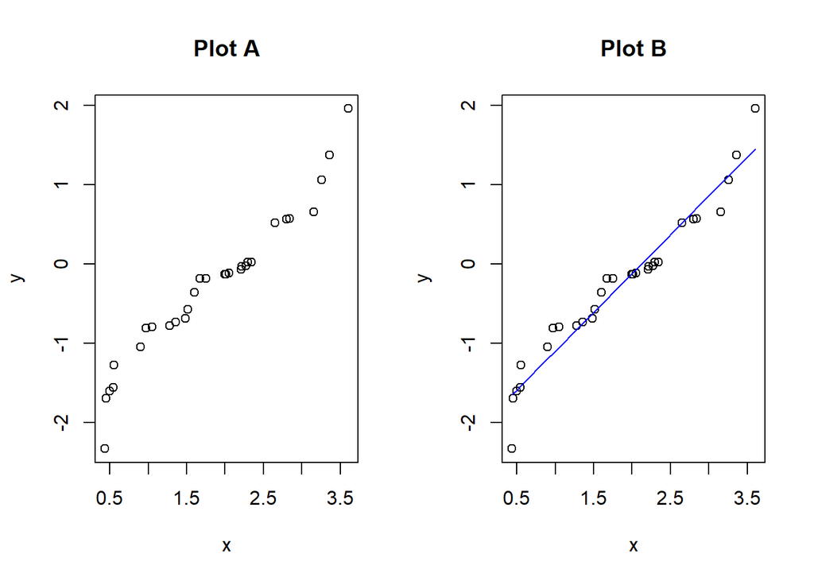

```r
x11() #forces a new device to be created
par(mfrow=c(1,2))
plot(x,y, main="Plot A")
plot(x,y, main="Plot B")
lines(x,lm(y~x)$fit, col="blue")
```

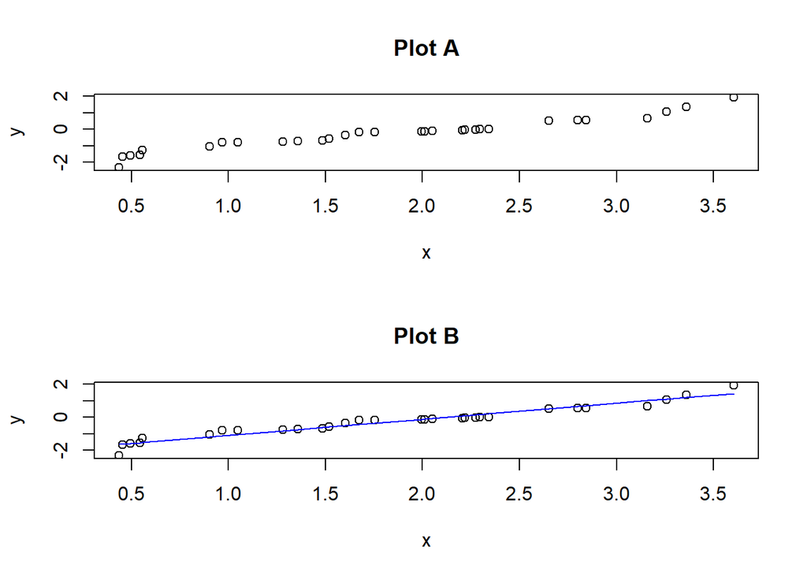

```r
x11()
par(mfrow=c(2,1))
plot(x,y, main="Plot A")
plot(x,y, main="Plot B")
lines(x,lm(y~x)$fit, col="blue")
```

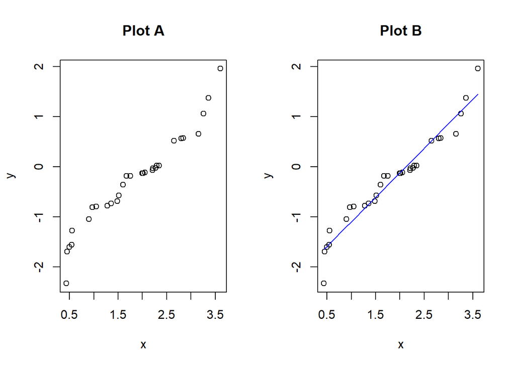

```r
x11()
par(mfcol=c(1,2))
plot(x,y, main="Plot A")
plot(x,y, main="Plot B")
lines(x,lm(y~x)$fit, col="blue")
```

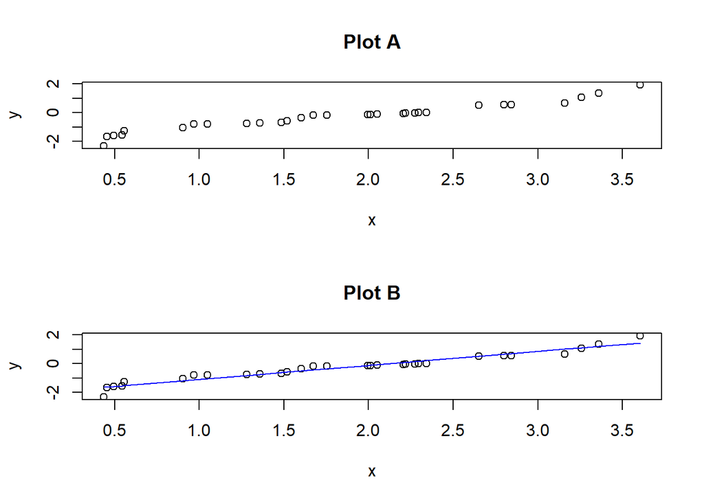

```r
x11()
par(mfcol=c(2,1))
plot(x,y, main="Plot A")
plot(x,y, main="Plot B")
lines(x,lm(y~x)$fit, col="blue")
```

```r
#Don't forget to change the graphics parameter back to the 1 by 1 matrix
par(mfrow=c(1,1))
```

### Saving multiple plots as image files

```r
rm(i)
pdf(file="plots.pdf")
mat <- matrix(runif(30*5), ncol=5 )
for(i in 2:ncol(mat))
  plot(mat[,1],mat[,i], type="p", pch=19, col=4) #we should probably add titles and labels
dev.off()
```